# Regression Model

Jackson Pham

2024-04-23

**Executive Summary**

This analysis uses the mtcars dataset to investigate the impact of transmission type on fuel efficiency, measured in miles per gallon (MPG). The results confirm that manual transmissions generally achieve higher MPG than automatics, with a coding of 0 for automatic transmission and 1 for manual transmission. Supported by statistical modeling and diagnostics, these findings underscore the fuel efficiency advantages of manual transmissions, providing valuable insights for consumers and the automotive industry. Conclusively, our analysis suggests that cars with manual transmission add an average of `14.079 + (-4.141) * wt` MPG compared to automatic transmission cars.

```r
# Load libraries
library(ggplot2)
```

**Exploratory Data Analysis**

```r
# Load the mtcars dataset
cars <- mtcars

# Convert the values in "am" column, 1 for automatic, and 0 for manual
cars$am <- factor(ifelse(cars$am == 0, "Automatic", "Manual"))

# View the dataset
head(cars)
```

```
##                    mpg cyl disp  hp drat    wt  qsec vs        am gear carb
## Mazda RX4         21.0   6  160 110 3.90 2.620 16.46  0    Manual    4    4
## Mazda RX4 Wag     21.0   6  160 110 3.90 2.875 17.02  0    Manual    4    4
## Datsun 710        22.8   4  108  93 3.85 2.320 18.61  1    Manual    4    1
## Hornet 4 Drive    21.4   6  258 110 3.08 3.215 19.44  1 Automatic    3    1
## Hornet Sportabout 18.7   8  360 175 3.15 3.440 17.02  0 Automatic    3    2
## Valiant           18.1   6  225 105 2.76 3.460 20.22  1 Automatic    3    1
```

**Inference**

```r
# Simple t.test on the mtcars data
cars_t_test <- t.test(mpg ~ am, data = cars)
cars_t_test$p.value
```

```
## [1] 0.001373638
```

With a p-value of 0.001373638 from the t-test, we reject the null hypothesis, indicating a significant difference in miles per gallon (mpg) between manual and automatic transmission.

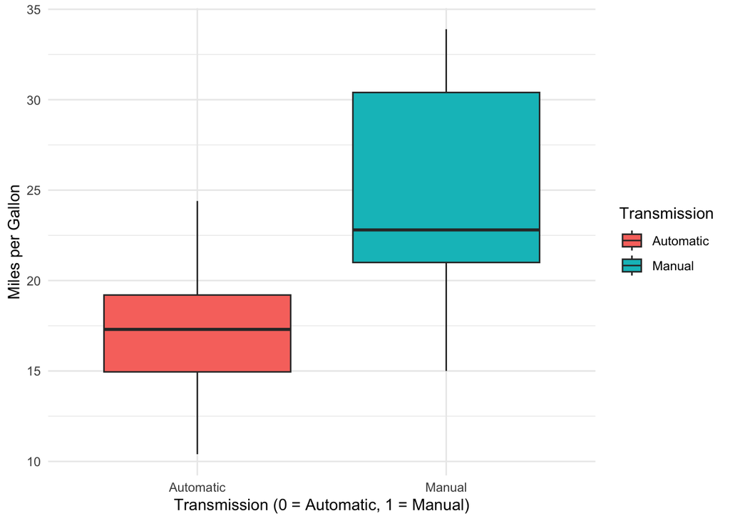

```r
# Perform some basic EDA. Plot the distribution of MPG for cars with manual and automatic transmissions to see if there's a visible difference.
cars_plot <- ggplot(cars, aes(x = factor(am), y = mpg, fill = factor(am))) +
  geom_boxplot() +
  labs(x = "Transmission (0 = Automatic, 1 = Manual)", y = "Miles per Gallon", fill = "Transmission") +
  theme_minimal()

# Print the plot
cars_plot
```

From the plot, it is evident that there is a significant difference in miles per gallon (MPG) between cars with automatic transmissions and those with manual transmissions.

**Statistical Modeling**

```r
# Full regression model to help finding the step model in the next step
full_fit <- lm(mpg ~ . , data = cars)

# Using step model to find the best fit regression
stepModel <- step(full_fit, k=log(nrow(cars)))
```

```
## Start:  AIC=87.02
## mpg ~ cyl + disp + hp + drat + wt + qsec + vs + am + gear + carb
##
##        Df Sum of Sq    RSS    AIC
## - cyl   1    0.0799 147.57 83.572
## - vs    1    0.1601 147.66 83.590
## - carb  1    0.4067 147.90 83.643
## - gear  1    1.3531 148.85 83.847
## - drat  1    1.6270 149.12 83.906
## - disp  1    3.9167 151.41 84.394
## - hp    1    6.8399 154.33 85.006
## - qsec  1    8.8641 156.36 85.423
## - am    1   10.5467 158.04 85.765
## <none>              147.49 87.021
## - wt    1   27.0144 174.51 88.937
##
## Step:  AIC=83.57
## mpg ~ disp + hp + drat + wt + qsec + vs + am + gear + carb
##
##        Df Sum of Sq    RSS    AIC
## - vs    1    0.2685 147.84 80.165
## - carb  1    0.5201 148.09 80.219
## - gear  1    1.8211 149.40 80.499
## - drat  1    1.9826 149.56 80.534
## - disp  1    3.9009 151.47 80.942
## - hp    1    7.3632 154.94 81.665
## - qsec  1   10.0933 157.67 82.224
## - am    1   11.8359 159.41 82.575
## <none>              147.57 83.572
## - wt    1   27.0280 174.60 85.488
##
## Step:  AIC=80.16
## mpg ~ disp + hp + drat + wt + qsec + am + gear + carb
##
##        Df Sum of Sq    RSS    AIC
## - carb  1    0.6855 148.53 76.847
## - gear  1    2.1437 149.99 77.160
## - drat  1    2.2139 150.06 77.175
## - disp  1    3.6467 151.49 77.479
## - hp    1    7.1060 154.95 78.201
```

[output cut: 44 more lines]

```
##        Df Sum of Sq    RSS    AIC
## - hp    1     9.219 169.29 67.170
## <none>              160.07 68.844
## - qsec  1    20.225 180.29 69.186
## - am    1    25.993 186.06 70.193
## - wt    1    78.494 238.56 78.147
##
## Step:  AIC=67.17
## mpg ~ wt + qsec + am
##
##        Df Sum of Sq    RSS    AIC
## <none>              169.29 67.170
## - am    1    26.178 195.46 68.306
## - qsec  1   109.034 278.32 79.614
## - wt    1   183.347 352.63 87.187
```

```r
# Extract coefficients
summary(stepModel)
```

```
##
## Call:
## lm(formula = mpg ~ wt + qsec + am, data = cars)
##
## Residuals:
##     Min      1Q  Median      3Q     Max
## -3.4811 -1.5555 -0.7257  1.4110  4.6610
##
## Coefficients:
##             Estimate Std. Error t value Pr(>|t|)
## (Intercept)   9.6178     6.9596   1.382 0.177915
## wt           -3.9165     0.7112  -5.507 6.95e-06 ***
## qsec          1.2259     0.2887   4.247 0.000216 ***
## amManual      2.9358     1.4109   2.081 0.046716 *
## ---
## Signif. codes:  0 '***' 0.001 '**' 0.01 '*' 0.05 '.' 0.1 ' ' 1
##
## Residual standard error: 2.459 on 28 degrees of freedom
## Multiple R-squared:  0.8497, Adjusted R-squared:  0.8336
## F-statistic: 52.75 on 3 and 28 DF,  p-value: 1.21e-11
```

Summary of the `lm(formula = mpg ~ wt + qsec + am, data = cars)` shows that it have 3 significant variable of wt, qsec, and am that the Adjusted R-squared value is 0.8336, which means that the model can explain about 83% of the variance of the MPG variable.

```r
# Further analysis of the regression model between wt and am
full_fit_adjusted <- lm(mpg ~ wt + qsec + am + wt:am, data = cars)

# Extract coefficients
summary(full_fit_adjusted)
```

```
##
## Call:
## lm(formula = mpg ~ wt + qsec + am + wt:am, data = cars)
##
## Residuals:
##     Min      1Q  Median      3Q     Max
## -3.5076 -1.3801 -0.5588  1.0630  4.3684
##
## Coefficients:
##             Estimate Std. Error t value Pr(>|t|)
## (Intercept)    9.723      5.899   1.648 0.110893
## wt            -2.937      0.666  -4.409 0.000149 ***
## qsec           1.017      0.252   4.035 0.000403 ***
## amManual      14.079      3.435   4.099 0.000341 ***
## wt:amManual   -4.141      1.197  -3.460 0.001809 **
## ---
## Signif. codes:  0 '***' 0.001 '**' 0.01 '*' 0.05 '.' 0.1 ' ' 1
##
## Residual standard error: 2.084 on 27 degrees of freedom
## Multiple R-squared:  0.8959, Adjusted R-squared:  0.8804
## F-statistic: 58.06 on 4 and 27 DF,  p-value: 7.168e-13
```

Including the interaction term `wt:am` in the model `lm(formula = mpg ~ wt + qsec + am, data = cars)` is essential to determine if the effect of a car’s weight on fuel efficiency varies with the type of transmission. The significance of this interaction indicates that the impact of weight on MPG changes depending on whether the car has a manual or automatic transmission.

The best_fit model yield R-adjusted value of 88.04% which means that the model can explain about 88% of the variance in MPG variable.

```r
# Using anova to find the best fit model
anova(full_fit_adjusted, full_fit)
```

```
## Analysis of Variance Table
##
## Model 1: mpg ~ wt + qsec + am + wt:am
## Model 2: mpg ~ cyl + disp + hp + drat + wt + qsec + vs + am + gear + carb
##   Res.Df    RSS Df Sum of Sq F Pr(>F)
## 1     27 117.28
## 2     21 147.49  6   -30.218
```

```r
# Pick the best model mpg ~ wt + qsec + am + wt:am with the highest R-adjusted value
summary(full_fit_adjusted)$coef
```

```
##              Estimate Std. Error   t value     Pr(>|t|)
## (Intercept)  9.723053  5.8990407  1.648243 0.1108925394
## wt          -2.936531  0.6660253 -4.409038 0.0001488947
## qsec         1.016974  0.2520152  4.035366 0.0004030165
## amManual    14.079428  3.4352512  4.098515 0.0003408693
## wt:amManual -4.141376  1.1968119 -3.460340 0.0018085763
```

Based on the result coefficient of the best_fit model, we can conclude that car with manual transmission add `14.079 + (-4.141) * wt` MPG on average compare to automatic transmission car.

**Residual Analysis and Diagnostics**

```r
# As for the Dfbetas, the measure of how much an observation has effected the estimate of a regression coefficient, this is the following result:
sum((abs(dfbetas(full_fit_adjusted)))>1)
```

```
## [1] 0
```

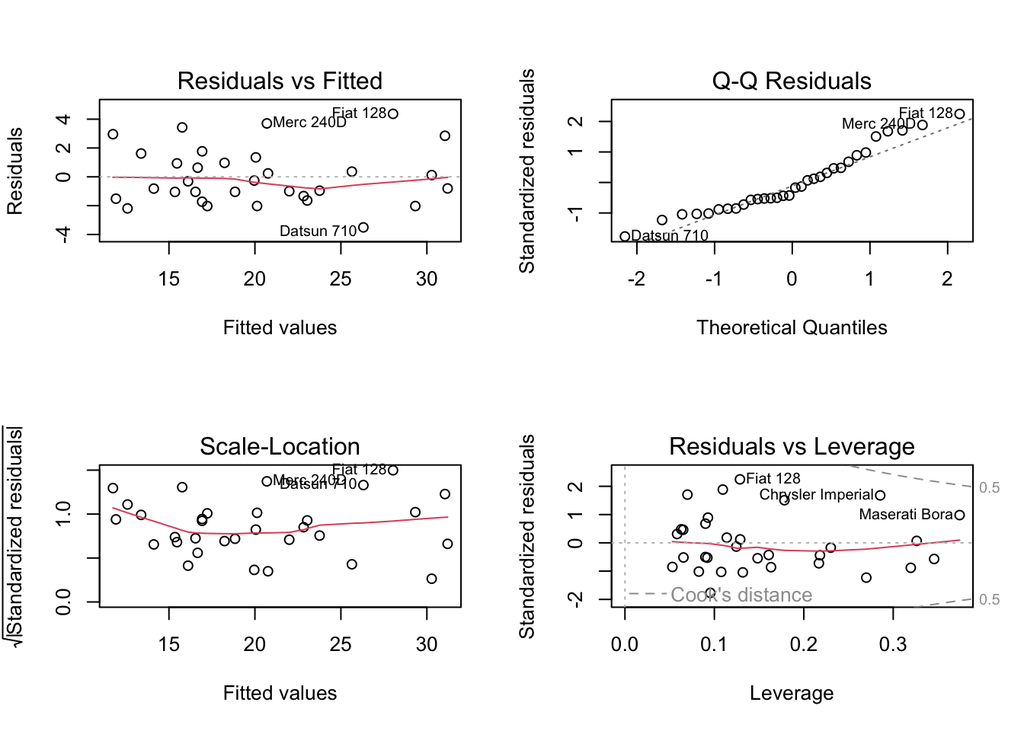

```r
# Plot statistical value
par(mfrow = c(2, 2))
plot(full_fit_adjusted)
```